# Презентация по лабораторной работе №15

Дисциплина: Администрирование локальных сетей

Лобанова П.И.

Российский университет дружбы народов, Москва, Россия

13 мая 2025

# Информация

## Докладчик

- Лобанова Полина Иннокентьевна
- Учащаяся на направлении “Фундаментальная информатика и информационные технологии”
- Студентка группы НФИбд-02-22
- polla-2004@mail.ru

# Цель

Настроить динамическую маршрутизацию между территориями организации.

# Задание

1. Настроить динамическую маршрутизацию по протоколу OSPF на маршрутизаторах msk-donskaya-gw-1, msk-q42-gw-1, msk-hostel-gw-1, sch-sochi-gw-1.
2. Настроить связь сети квартала 42 в Москве с сетью филиала в г. Сочи напрямую.
3. В режиме симуляции отследить движение пакета ICMP с ноутбука администратора сети на Донской в Москве (Laptop-PT admin) до компьютера пользователя в филиале в г. Сочи pc-sochi-1.
4. На коммутаторе провайдера отключить временно vlan 6 и в режиме симуляции убедиться в изменении маршрута прохождения пакета ICMP с ноутбука администратора сети на Донской в Москве (Laptop-PT admin) до компьютера пользователя в филиале в г. Сочи pc-sochi-1.
5. На коммутаторе провайдера восстановить vlan 6 и в режиме симуляции убедиться в изменении маршрута прохождения пакета ICMP с ноутбука администратора сети на Донской в Москве (Laptop-PT admin) до компьютера пользователя в филиале в г. Сочи pc-sochi-1.
6. При выполнении работы необходимо учитывать соглашение об именовании.

# Выполнение

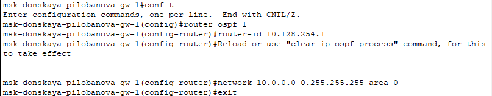

*Настройка маршрутизатора msk-donskaya-gw-1*

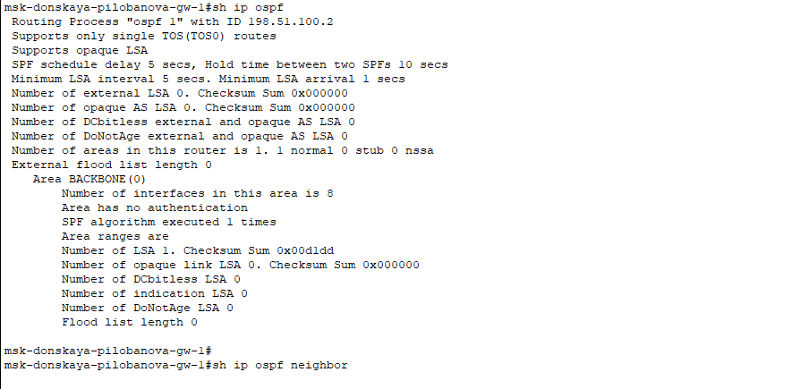

*Проверка состояния протокола OSPF на маршрутизаторе msk-donskaya-gw-1*

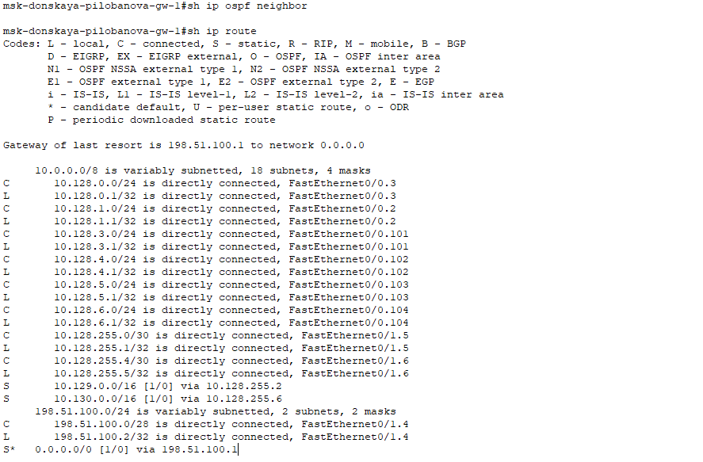

*Проверка состояния протокола OSPF на маршрутизаторе msk-donskaya-gw-1*

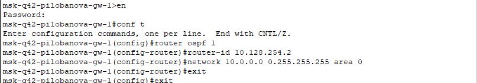

*Настройка маршрутизатора msk-q42-gw-1*

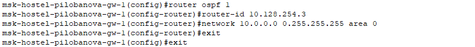

*Настройка маршрутизирующего коммутатора msk-hostel-gw-1*

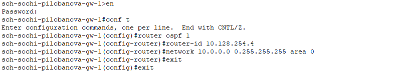

*Настройка маршрутизатора sch-sochi-gw-1*

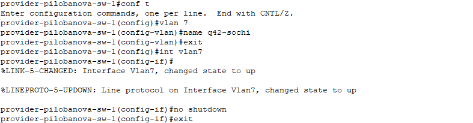

*Настройка интерфейсов коммутатора provider-sw-1*

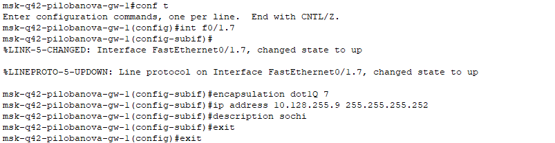

*Настройка маршрутизатора msk-q42-gw-1*

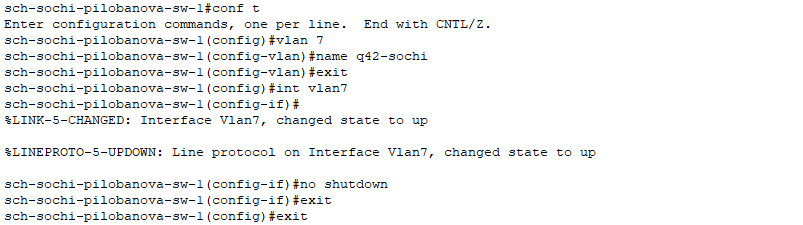

*Настройка коммутатора sch-sochi-sw-1*

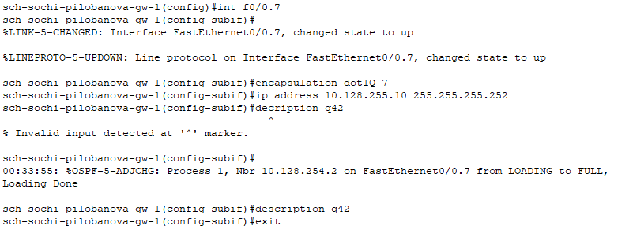

*Настройка маршрутизатора sch-sochi-gw-1*

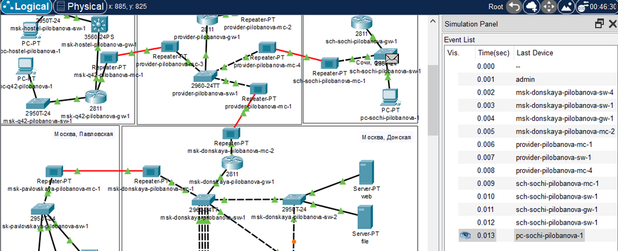

*Путь пакета ICMP с ноутбука администратора сети на Донской до компьютера пользователя г. Сочи*

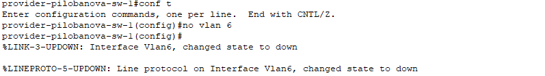

*Отключение vlan 6*

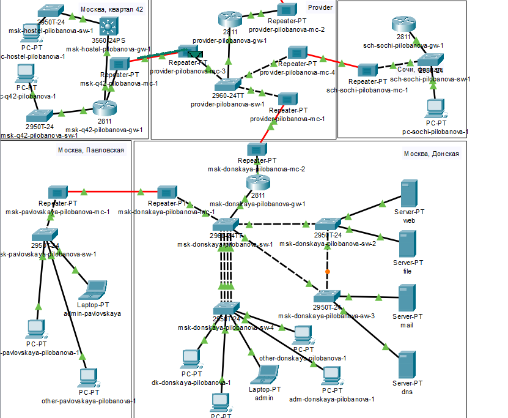

*Путь пакета ICMP с ноутбука администратора сети на Донской до компьютера пользователя г. Сочи*

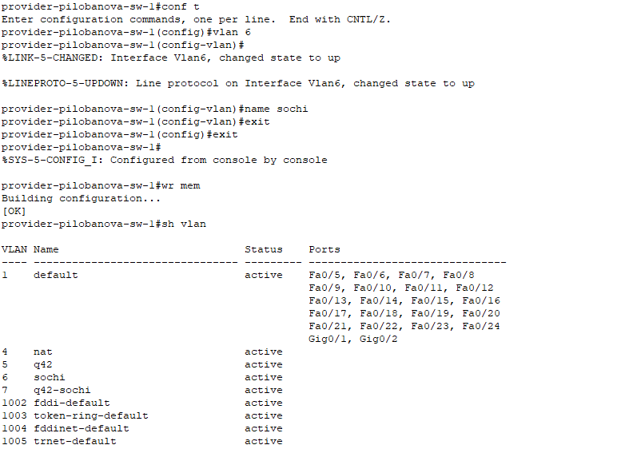

*Восстановление vlan 6*

[figure not shown]

*Путь пакета ICMP с ноутбука администратора сети на Донской до компьютера пользователя г. Сочи*

# Вывод

Я настроила динамическую маршрутизацию между территориями организации.